# Interactive Data Analysis with Python

[figure not shown]

## Objectives

- Become familiar with the **IPython Notebook**.
- Introduce the **pandas** library.
- How do you currently:
  - wrangle data?
  - visualize results?
  - Analysis: machine learning, stats
  - Parallel computing
  - Big data

## What is Python?

> Python is a general-purpose programming language that blends procedural, functional, and object-oriented paradigms

> Mark Lutz, [Learning Python](http://www.amazon.com/Learning-Python-Edition-Mark-Lutz/dp/1449355730)
- Simple, clean syntax
- Easy to learn
- Interpreted
- Strong, dynamically typed
- Runs everywhere: Linux, Mac, and Windows
- [Free](http://www.fsf.org/) and open
- Expressive: do more with fewer lines of code
- Lean: **modules**
- Options: **Procedural**, **object-oriented**, and **functional**.

### Abstractions

[figure not shown]

## IPython Notebook

Interactive web-based computing, data analysis, and documentation.

- One document for code and output
- Run locally and remote
- Document process
- Share results

[figure not shown]

### Does not separate code and text

- Data structure ouput
- Inline plots
- Conversation sytle programming ([Literate programming](http://en.wikipedia.org/wiki/Literate_programming))
- Telling a data story
- Great for *iterative* programming.
  - Data analysis
  - Quick scripts
  - Prototyping

### Locally and Remote

- Run locally
- Connect to the cloud (e.g [AWS](http://aws.amazon.com/))
- Connect to supercomputer (e.g. XSEDE Resource)
- Add compute power:
  - [mpi4py](http://mpi4py.scipy.org/)
  - [IPython Parallel](http://ipython.org/ipython-doc/dev/parallel/)
  - [spark](http://spark.incubator.apache.org/) big distributed data
  - [Numbapro](http://docs.continuum.io/numbapro/) GPU
  - ...

### Documentation and Sharing

[figure not shown]

### Keyboard Shortcuts

[figure not shown]

### `Markdown` and `Latex`

- `Markdown`
- Latex $y = \sqrt{a + b}$
- one

### Images

```
<img src='https://s3.amazonaws.com/research_computing_tutorials/monty-python.png' width="300">
```

This is an image:

[figure not shown]

### Video

```python
from IPython.display import YouTubeVideo
YouTubeVideo('F4rFuIb1Ie4', start=2400, width=600, height=400)
```

[video not shown]

### Embeded plots

```python
%matplotlib inline
import matplotlib.pyplot as plt
import utils #plot format
reload(utils)
import numpy as np
x = np.random.randn(10000)
```

What does $x$ look like?

```python
x
```

```
array([-1.58434326,  0.05214036, -0.15380455, ...,  0.13404652,
        0.24362133, -1.57808357])
```

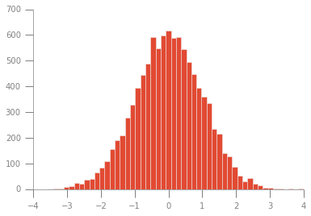

```python
plt.hist(x, bins=50)
plt.show()
```

### Customizable

- Custom `CSS`
- Custom `javascript` libraries
- Create your own output format.
- Tools and workflow

### Magic Commands

- Built-in useful functions
- `%` line commands
- `%%` cell commands

### Write to a file.

```python
%%writefile example.py

def hello():
    print 'hello'
```

### Load a file into a Notebook.

```python
%load example.py
```

```python
def hello():
    print 'hello'
```

```python
hello()
```

### Execute a file

Great for working with your own files.

```python
%%writefile example.py

def get():
    return 10

A = get()
```

```python
%run example.py

print A
```

**Notice** that `A` is now available.

### `import` and `reload`

Great for working with your own `modules`.

```python
import example as ex
reload(ex)

print ex.get()
```

### Other Languages: Bash

```python
%%bash
ls -l
```

```python
files = !ls # But glob is a better way
print files[:5]
```

### Keep it all together

```python
%%writefile example.cpp
#include <iostream>

int main(){
    std::cout << "hello from c++" << std::endl;
}
```

```python
%%bash
g++ example.cpp -o example
./example
```

## NBconvert examples

- HTML
- PDF (print)
- Slides
- Dynamic Slides
- ReStructured Text ([sphinx](http://sphinx-doc.org/))